# hw3

Problem 3

Let i be the index of an example. We can compute all the weight terms immediately by $w = w + \alpha {x^{(i)}}^T(y^{(i)}-h_{w}(x^{(i)}))$  
w = $\begin{bmatrix} 0 \\ 0 \\ 1 \end{bmatrix}$  
i = 1:  
$x^{(1)}w = \begin{bmatrix} 1 & 1 & 1 \end{bmatrix} \begin{bmatrix} 0 \\ 0 \\ 1 \end{bmatrix} = 1 $  
$h_{w}(x^{(1)}) = 1 $  
w = $\begin{bmatrix} 0 \\ 0 \\ 1 \end{bmatrix}+0.5 \begin{bmatrix} 1 \\ 1 \\ 1 \end{bmatrix}(0-1)= \begin{bmatrix} -0.5 \\ -0.5 \\ 0.5 \end{bmatrix}$  
Check if class correctly:  
Xw = $\begin{bmatrix} 1 & 1 & 1 \\ 1 & 2 & 2 \\ 1 & 3 & 4 \\ 1 & 2 & 4.5 \\ 1 & 3 & 6 \end{bmatrix} \begin{bmatrix} -0.5 \\ -0.5 \\ 0.5 \end{bmatrix} = \begin{bmatrix} -0.5 \\ -0.5 \\ 0 \\ 0.75 \\ 1 \end{bmatrix} $  
$h_w(X)= \begin{bmatrix} 0 \\ 0 \\ 1 \\ 1 \\ 1 \end{bmatrix} $ Not class correctly, continue  
i=2:  
$x^{(2)}w = \begin{bmatrix} 1 & 2 & 2 \end{bmatrix} \begin{bmatrix} -0.5 \\ -0.5 \\ 0.5 \end{bmatrix} = -0.5 $  
$h_{w}(x^{(2)}) = 0 $  
w = $\begin{bmatrix} -0.5 \\ -0.5 \\ 0.5 \end{bmatrix}+0.5 \begin{bmatrix} 1 \\ 2 \\ 2 \end{bmatrix}(0-0)= \begin{bmatrix} -0.5 \\ -0.5 \\ 0.5 \end{bmatrix}$  
w does not change, continue i=3:  
$x^{(3)}w = \begin{bmatrix} 1 & 3 & 4 \end{bmatrix} \begin{bmatrix} -0.5 \\ -0.5 \\ 0.5 \end{bmatrix} = 0 $  
$h_{w}(x^{(3)}) = 1 $  
w = $\begin{bmatrix} -0.5 \\ -0.5 \\ 0.5 \end{bmatrix}+0.5 \begin{bmatrix} 1 \\ 3 \\ 4 \end{bmatrix}(0-1)= \begin{bmatrix} -1 \\ -2 \\ -1.5 \end{bmatrix}$  
Check if class correctly:  
Xw = $\begin{bmatrix} 1 & 1 & 1 \\ 1 & 2 & 2 \\ 1 & 3 & 4 \\ 1 & 2 & 4.5 \\ 1 & 3 & 6 \end{bmatrix} \begin{bmatrix} -1 \\ -2 \\ -1.5 \end{bmatrix} = \begin{bmatrix} -4.5 \\ -8 \\ -13 \\ -11.75 \\ -16 \end{bmatrix} $  
$h_w(X)= \begin{bmatrix} 0 \\ 0 \\ 0 \\ 0 \\ 0 \end{bmatrix} $ Not class correctly, continue  
i=4:  
$x^{(4)}w = \begin{bmatrix} 1 & 2 & 4.5 \end{bmatrix} \begin{bmatrix} -1 \\ -2 \\ -1.5 \end{bmatrix} = -11.75 $  
$h_{w}(x^{(3)}) = 0 $  
w = $\begin{bmatrix} -1 \\ -2 \\ -1.5 \end{bmatrix}+0.5 \begin{bmatrix} 1 \\ 2 \\ 4.5 \end{bmatrix}(1-0)= \begin{bmatrix} -0.5\\ -1 \\ 0.75 \end{bmatrix}$  
Check if class correctly:  
Xw = $\begin{bmatrix} 1 & 1 & 1 \\ 1 & 2 & 2 \\ 1 & 3 & 4 \\ 1 & 2 & 4.5 \\ 1 & 3 & 6 \end{bmatrix} \begin{bmatrix} -0.5\\ -1 \\ 0.75 \end{bmatrix} = \begin{bmatrix} -0.75 \\ -1 \\ -0.5 \\ 0.875 \\ 1 \end{bmatrix} $  
$h_w(X)= \begin{bmatrix} 0 \\ 0 \\ 0 \\ 1 \\ 1 \end{bmatrix} $ class correctly

Problem 4

(a)

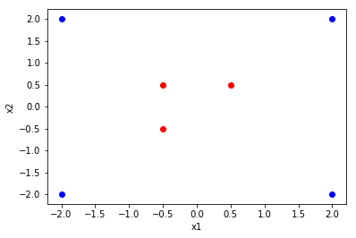

```python
plt.scatter([0.5,-0.5,-0.5],[0.5,0.5,-0.5],color='red')
plt.scatter([2,2,-2,-2],[2,-2,2,-2],color='blue')
plt.xlabel('x1')
plt.ylabel('x2')
plt.show()
```

The boundary I choose is a circle $x^2+y^2=1$

(b)Using perceptron updating algorithm. And let + be 1, - be 0  
Let w = $\begin{bmatrix} 9 \\ -1 \\ -1 \end{bmatrix}$ i=1:  
$x^{(1)}w = \begin{bmatrix} 1 & 0.25 & 0.25 \end{bmatrix} \begin{bmatrix} 9 \\ -1 \\ -1 \end{bmatrix} = 8.5 $  
$h_{w}(x^{(1)}) = 1 $  
So $y-h_{w}(x^{(1)}) = 1-1 = 0$, w will not change  
Thus we can skip example 2 and 3.  
i=4:  
$x^{(4)}w = \begin{bmatrix} 1 & 4 & 4 \end{bmatrix} \begin{bmatrix} 9 \\ -1 \\ -1 \end{bmatrix} = 1 $ $h_{w}(x^{(1)}) = 1 $  
$w = \begin{bmatrix} 9 \\ -1 \\ -1 \end{bmatrix}+ \begin{bmatrix} 1 \\ 4 \\ 4 \end{bmatrix}(0-1)= \begin{bmatrix} 8 \\ -5 \\ -5 \end{bmatrix}$  
$Xw = \begin{bmatrix} 1 & 0.25 & 0.25 \\ 1 & 0.25 & 0.25 \\ 1 & 0.25 & 0.25 \\ 1 & 4 & 4 \\ 1 & 4 & 4 \\ 1 & 4 & 4 \\ 1 & 4 & 4 \end{bmatrix} \begin{bmatrix} 8 \\ -5 \\ -5 \end{bmatrix}= \begin{bmatrix} 5.5 \\ 5.5 \\ 5.5 \\ -32 \\ -32 \\ -32 \\ -32 \end{bmatrix} $  
$hw(X) = \begin{bmatrix} 1 \\ 1 \\ 1 \\ 0 \\ 0 \\ 0 \\ 0 \end{bmatrix} $Class correctly  
(c)  
$p(x^{(1)}) = \dfrac{1}{1+e^{-5.5}} \approx 0.996$  
$p(x^{(3)}) = \dfrac{1}{1+e^{-5.5}} \approx 0.996$